# Can Monkeys Beat Humans in the Stock Market?

Jared Gill, Kalinda Vathupola

May 22, 2019

Abstract

In this project, we compare the performance of two portfolios, both with an initial capital of $1,000,000: one is managed by monkeys, the other by humans. The former portfolio is constructed by randomized stock picks. The latter portfolio is constructed using a multi-factor valuation model adhering to Arbitrage Pricing Theory with a basic allocation model. Performance is assessed in terms of portfolio value at the end of the testing period.

# 1 Legal

Data provided for free by [IEX](https://iextrading.com/developer/). View [IEX’s Terms of Use](https://iextrading.com/api-exhibit-a/).

Note that this service will be deprecated on June 1, 2019. To use a similar service, see [IEX Cloud](https://iexcloud.io). Furthermore, consult its [terms of service](https://iexcloud.io/terms/).

# 2 Introduction

The objective of this tutorial is to provide a motivated project as an example of using R in a realistic application. This project seeks to answer a simple question: Who would be better at picking stocks: Monkeys or Humans? Is the stock market a game of skill or luck? Let’s find out!

**Important Note**: Consult the **glossary** for detailed information on most financial terms used in this project.

## 2.1 Hypothesis

Our hypothesis is:

Humans outperform monkeys in portfolio management.

## 2.2 Experimental Significance

At first glance, our experiment appears to be nothing more than an attempt to answer a juvenile curiosity of little practical importance. Its actual implications, however, are quite significant.

The actual question is: does the application of quantitative financial theory improve the ability of portfolio managers to gain superior returns? If humans succeed over the monkeys, the answer is affirmative. The “monkey” portfolio is merely a proxy for a randomly constructed one. The specific financial theory to be tested is Arbitrage Pricing Theory, which makes use of multilinear regression to predict equity returns.

Yet the question remains: Is there any point in applying sophisticated data science to merely get money? From a business standpoint, the answer is clearly a “yes.” Asset management firms, be it for high-net worth clients or pension funds, will be able to increase economic efficiency by supplanting the work of many financial analysts with a few data scientists, thereby increasing employee and client returns. From a data-science standpoint, financial models returns can have their fundamental theory applied to other cases concerning stochastic forecasting, such as fluid dynamics, tumor growth etc. Indeed, physical [models of Brownian motion](https://en.wikipedia.org/wiki/Ornstein%E2%80%93Uhlenbeck_process#Application_in_financial_mathematics) have found use in finance.

## 2.3 Experimental Procedure

This experiment is divided into three stages, which will be presented sequentially:

1. The construction of the monkey portfolio
   - Initial capital of 1,000,000 dollars
   - Each trading week, select a stock. Buy as many shares of this stock as possible. At week’s end, sell all shares and repeat this process for another, randomly chosen stock.
   - Test Period: Jan. 2017 to May 2019
2. The construction of the human portfolio
   - Initial capital of 1,000,000 dollars
   - Each trading week, select the stock with the highest expected return, as determined by our regression model. Buy as many shares of this stock as possible. At week’s end, sell all shares and repeat this process for another stock.
   - Training Period: May 2014 to Jan. 2017
   - Test Period: Jan. 2017 to May 2019
3. Assessment of portfolio performance

**Note**: A trading week is not 7 days (traders need weekends off too)! A trading week is typically 5 days. We extrapolate the number of trading days in a month and year similarly from average metrics.

As stated previously, the “monkey” portfolio is merely a proxy term for a randomly-constructed portfolio devoid of financial theory. The human portfolio applies Arbitrage Pricing Theory to model daily stock returns as a multilinear regression model.

Though there exist many metrics for assessing portfolio performance, we use total portfolio value for simplicity of computation and brevity of explanation.

Before we begin the construction of either portfolio, let’s load the libraries:

```r
library(jsonlite)
library(httr)
library(tidyverse)
library(dplyr)
library(zoo)
library(RcppRoll)
library(tibble)
theme_set(theme_minimal())
```

# 3 Creating the Monkey Portfolio

## 3.1 Loading Data

We will be getting the stock data that we need using the Investors Exchange (IEX) API. You can read more about this dataset here: https://iextrading.com/developer/docs/ Let’s get stock data over the last 2 years for Apple to start.

```r
#collect data
r <- GET("https://api.iextrading.com/1.0/stock/market/batch",
         query = list(symbols = "aapl",
                      types = "chart",
                      range = "2y", last = "5")
)
```

To get the data, we will be using an HTTP request that will return data in a JSON format. To learn more about JSON, check out the wikipedia article here: https://en.wikipedia.org/wiki/JSON

## 3.2 Data Preparation

Congrats! We have some data. However, as you may notice, there isn’t any way to conveniently use this data. We want to get the data into a more usable format. Let’s start by unpacking the JSON formatted data into a more readable format:

```r
#upack data
r1 <- content(r)
rappl <- enframe(unlist(r1$AAPL$chart))

#pull out relevant data
rappl_dates <- filter(rappl, name=="date")
rappl_close <- filter(rappl, name=="close")

#put data into a single dataframe
df <- data.frame(rappl_dates[2], rappl_close[2])
df <- df %>%
  dplyr::rename(date="value", aapl_close="value.1")

head(df)
```

```
##         date aapl_close
## 1 2017-05-22   149.3592
## 2 2017-05-23   149.1749
## 3 2017-05-24   148.7288
## 4 2017-05-25   149.2428
## 5 2017-05-26   148.9906
## 6 2017-05-30   149.0488
```

You should get a dataframe that looks similar to this. Going forward we will need to do this process for multiple stocks and get more attributes for each, so lets put all of this into a function which we can call repeatedly.

```r
#function to return dataframe of date, close, high, low, volume for ticker
iex_chart <- function(tick, range){
  r <- GET("https://api.iextrading.com/1.0/stock/market/batch",
           query = list(symbols = tick,
                        types = "chart",
                        range = range, last = "5")
  )
  r1 <- content(r)
  rtick <- enframe(unlist(r1[[tick]]$chart))
  rdates <- filter(rtick, name=="date")
  rclose <- filter(rtick, name=="close")
  rhigh <- filter(rtick, name=="high")
  rlow <- filter(rtick, name=="low")
  rvolume <- filter(rtick, name=="volume")
  df <- data.frame(rdates[2], rclose[2], rhigh[2], rlow[2], rvolume[2])
  df <- df %>%
    dplyr::rename(date="value", close="value.1", high="value.2", low="value.3", volume="value.4")
  return(df)
}

#this funciton can be called with just the stock ticker and the timeframe
head(iex_chart("AAPL","2y"))
```

```
##         date    close     high      low   volume
## 1 2017-05-22 149.3592 149.9315 148.3117 22966437
## 2 2017-05-23 149.1749 150.2418 148.6997 19918871
## 3 2017-05-24 148.7288 149.5338 148.0789 19219154
## 4 2017-05-25 149.2428 149.7084 148.4281 19235598
## 5 2017-05-26 148.9906 149.6017 148.6997 21927637
## 6 2017-05-30 149.0488  149.786 148.7191 20126851
```

## 3.3 Preparing Monkey Data

Now time to set up our experiment. We will need a dataframe over which our monkeys can make random stock picks and see how their investments pan out.  
First, let’s get a bunch of data. We used the method above to get data for 6 stocks over 5 years and saved it as a CSV earlier, so now lets just read that data in. We are going to put all this data into a single dataframe, so let’s also rename the columns so we can tell the data apart.

```r
#Prepare monkey data
aapl_df <- read_csv("./data/aapl.csv") %>%
  dplyr::rename(aapl_close="close", aapl_high="high", aapl_low="low",
                aapl_vol="volume", aapl_change="change")
cone_df <- read_csv("./data/cone.csv") %>%
  dplyr::rename(cone_close="close", cone_high="high", cone_low="low",
                cone_vol="volume", cone_change="change")
fb_df <- read_csv("./data/fb.csv") %>%
  dplyr::rename(fb_close="close", fb_high="high", fb_low="low",
                fb_vol="volume", fb_change="change")
goog_df <- read_csv("./data/goog.csv") %>%
  dplyr::rename(goog_close="close", goog_high="high", goog_low="low",
                goog_vol="volume", goog_change="change")
govt_df <- read_csv("./data/govt.csv") %>%
  dplyr::rename(govt_close="close", govt_high="high", govt_low="low",
                govt_vol="volume", govt_change="change")
vz_df <- read_csv("./data/vz.csv") %>%
  dplyr::rename(vz_close="close", vz_high="high", vz_low="low",
                vz_vol="volume", vz_change="change")

#join into one data frame
df <- plyr::join_all(list(aapl_df,cone_df,fb_df,
                    goog_df,govt_df,vz_df),
               by='date', type='left')

head(df)
```

```
##         date aapl_close aapl_high aapl_low aapl_vol aapl_change cone_close
## 1 2014-05-12    77.6204   77.7290  76.9094 53324677    0.954164    18.4400
## 2 2014-05-13    77.7421   77.8443  77.3415 39934594    0.121767    18.5244
## 3 2014-05-14    77.7565   78.2187  77.4777 41600846    0.014404    18.4907
## 4 2014-05-15    77.0953   78.1140  76.9932 57711731   -0.661206    18.4653
## 5 2014-05-16    78.2331   78.2358  76.6475 69091834    1.137800    18.6512
## 6 2014-05-19    79.1601   79.5189  78.2096 79439024    0.926995    18.5413
##   cone_high cone_low cone_vol cone_change fb_close fb_high fb_low   fb_vol
## 1   18.6680  18.2288   130131    0.211179  59.8300   59.90  57.98 48575487
## 2   18.7103  18.3639   157313    0.084472  59.8300   60.89  59.51 48525476
## 3   18.6765  18.2879   104227   -0.033789  59.2300   60.45  58.95 47428583
## 4   18.7035  18.0852   167331   -0.025342  57.9190   59.38  57.52 56813940
## 5   18.7694  18.1866   239721    0.185834  58.0199   58.45  57.31 47933075
## 6   18.9046  18.4653   106110   -0.109812  59.2100   59.56  57.57 43033925
##   fb_change goog_close goog_high goog_low goog_vol goog_change govt_close
```

[output cut: 20 more lines]

We want to focus on a specific period of time, and to do that we will need to compare dates. Let’s turn our date column entries into date objects so we can compare them to each other easily.

```r
#make date into date object
df <- df %>%
  type_convert(col_types = cols(date = col_date(format = "%Y-%m-%d")))
```

Now monkeys aren’t very smart, so they will only care about the closing price of the stock for a given day. Let’s get rid of the rest of the columns for now.

```r
#select date and close for each stock
df <- select(df,date,aapl_close,cone_close,fb_close,goog_close,govt_close,vz_close)

head(df)
```

```
##         date aapl_close cone_close fb_close goog_close govt_close vz_close
## 1 2014-05-12    77.6204    18.4400  59.8300     529.92    22.8782  38.3433
## 2 2014-05-13    77.7421    18.5244  59.8300     533.09    22.9059  38.0965
## 3 2014-05-14    77.7565    18.4907  59.2300     526.65    23.0077  38.2239
## 4 2014-05-15    77.0953    18.4653  57.9190     519.98    22.9893  38.1841
## 5 2014-05-16    78.2331    18.6512  58.0199     520.63    23.0051  39.0678
## 6 2014-05-19    79.1601    18.5413  59.2100     528.86    22.9523  39.1315
```

We now have a dataframe that is ready for the monkey side of the experiment.

## 3.4 Monkey Experiment

The monkeys will buy a new stock every week (5 business days). We can pick every 5th entry using the slice command. Also, we will be testing the monkeys over a specific period, so let’s also filter out any rows that don’t fall between our test period, from 1/03/17 to 05/10/2019.

```r
#keep data for testing period, 1/03/2017 - 05/10/2019
df <- filter(df, as.POSIXct(date) >= as.POSIXct("2017-01-03") &
           as.POSIXct(date) <= "2019-05-10")
#take every 5th value to get one per week
df <- slice(df, seq(2, nrow(df), by=5))
```

We use the function as.POSIXct as a way to easily compare dates. Now give our monkeys some money and see how they do. First, create an empty column which will be the monkeysportfolio, and start them off with a small loan of a million dollars.

```r
#create empty column which will be for portfolio
df$portfolio_val <- NA #blank column
df$portfolio_val[1] <- 1000000 #start off with $1,000,000
```

We are ready for the monkeys to make their stock picks. The monkeys will operate in the following fashion:

1. Pick a stock out of the 6 options at random to buy
2. Buy as many of that stock as they can afford with what is in the portfolio
3. Sell them next week and do the same thing for a newly chosen stock

Here is that process in action:

```r
for(i in 2:nrow(df)){
  #choose a random stock
  pick = floor(runif(1, min=2, max=8))
  prev_close = ifelse(pick==2, df$aapl_close[i-1],
                  ifelse(pick==3, df$cone_close[i-1],
                    ifelse(pick==4, df$fb_close[i-1],
                      ifelse(pick==5, df$goog_close[i-1],
                        ifelse(pick==6, df$govt_close[i-1],
                          ifelse(pick==7, df$vz_close[i-1], 0))))))
  num_shares = df$portfolio_val[i-1]/prev_close
  curr_close = ifelse(pick==2, df$aapl_close[i],
                ifelse(pick==3, df$cone_close[i],
                  ifelse(pick==4, df$fb_close[i],
                    ifelse(pick==5, df$goog_close[i],
                      ifelse(pick==6, df$govt_close[i],
                        ifelse(pick==7, df$vz_close[i], 0))))))
  df$portfolio_val[i] = num_shares*curr_close
}
#The long if statements are necessary due to the random picks and some quirks
#of the r language.  This will work for our small experiment, however this
#workaround would not scale well in a practical version.
```

We now have our monkey stock performance. We can calculate how well the monkeys did but looking at their net portfolio change for each week, and plot this over time to get an overall sense of their performance.

**Note**: This data is dynamically generated from our JSON call. Thus, it is execution dependent. Recall that we recorded the performance of our monkey portfolio in a single run by CSV file in order to allow stable comparison with our human portfolio.

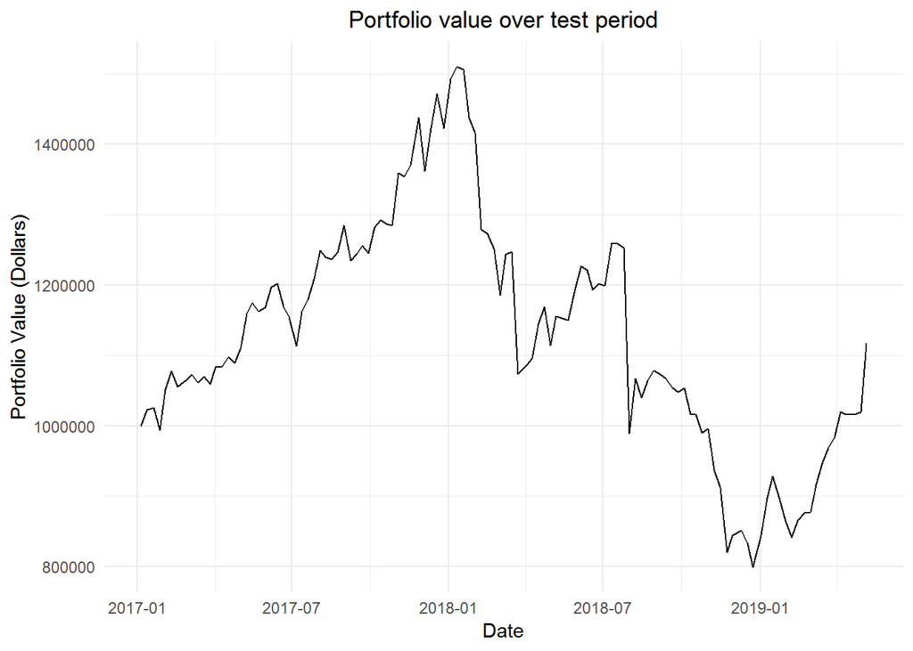

```r
monkey_df <- df %>%
  select(date, portfolio_val) %>%
  mutate(net_portfolio_change = portfolio_val - 1000000)

#plot monkey returns
monkey_df %>%
  ggplot(mapping=aes(x=date, y=portfolio_val)) + geom_line()+
    labs(title="Portfolio value over test period",
         x = "Date",
         y = "Portfolio Value (Dollars)") +
    theme(plot.title = element_text(hjust = 0.5))
```

Let’s write this data to a file and hold onto it for now.

**Note**: In practice, this was done once so as to minimize the tutorial’s dependence on the time of JSON call.

```r
write_csv(monkey_df, "monkey_df.csv")
```

# 4 Creating the Human Portfolio

## 4.1 Theoretical Overview

Before we can start constructing our portfolio, we need to understand what we’re trying to achieve! To this end, we need to understand the financial theory being applied. Much of this material is adapted from the following, wonderful text:

[Fabozzi, Frank J., et al. Financial Modeling of the Equity Market: from CAPM to Cointegration. Wiley, 2006.](https://onlinelibrary.wiley.com/doi/book/10.1002/9781119201236)

For the sake of brevity, we provide a high-level overview. If this is still not sufficient, consult the textbook above.

Fundamentally, we wish to train a regression model on training data. This model is then applied to unseen test data in order to forecast the daily returns of equities. This model is then used for investment decisions by, in our case, investing all of our capital in stocks with the greatest expected return.

## 4.2 Delving into Theory

We use the following regression model:

$$E(R_i) = R_f + \sum_{k=1}^N \beta_{ik} \big( E(F_k) - R_f \big) + \varepsilon,$$
where $R_i$ is the return of the $i$th asset, $E(F_k)$ is the expected value of the $k$th factor, $R_f$ is the risk-free rate and $\varepsilon$ is the error term. But why do we use *this* model? What do these terms mean? The answer lies in Arbitrage Pricing Theory

### 4.2.1 Arbitrage Pricing Theory

According to general financial theory, a portfolio is fundamentally composed of risky and riskless assets. An asset is said to be riskless if it has a constant rate of return, the risk-free rate $R_f$. Conversely, the return of a risky asset is variable.

Of course, no asset is truly riskless. Thus, portfolio managers supplant a risk-free asset with one of little risk, such as 10 year U.S. Treasury notes (T-Bill).

In our human portfolio, we take the iShares Core U.S. Treasury Bond ETF as the riskless asset. Unlike T-Bills, we need not wait until maturation to realize our return, thereby allowing us to define the risk-free rate for shorter time-intervals, namely our weekly holding period.

Risk belongs to one of two categories:

- Systematic Risk: Risk that is not diversifiable
- Unsystematic Risk: Risk that is diversifiable

Risk is said to be diversifiable if the strategic allocation of a portfolio into certain financial instruments can lower the level of risk. Thus, systematic risk can be viewed as risk inherent to the market that cannot be eliminated. Unsystematic risk can be viewed as risk inherent to specific assets that can be lowered by adjusting our portfolio’s exposure to said asset.

Arbitrage Pricing Theory (APT) assumes the following Theorem:

For a fixed time, the transaction cost for an asset is fixed.

This implies that the existence of arbitrage (a price differential that thereby allows for risk-less profit) is fleeting and will be eliminated by the market. Thus, risky asset cannot be rendered risk-less. Furthermore, ABT assumes that investors are compensated with superior returns, defined as returns in excess of the risk-free rate, for taking risk that cannot be diversified away: systematic risk. Otherwise, were investors compensated for risk that can be diversified, we would have arbitrage.

Let’s return to our model to bring everything together

### 4.2.2 Returning to Our Model

Recall the model:
$$E(R_i) = R_f + \sum_{k=1}^N \beta_{ik} \big( E(F_k) - R_f \big) + \varepsilon,$$
With our knowledge of ABT, we now see that

- $F_k$ is the $k$th of $N$ total systematic risk factors that explain returns on the $i$th asset
- $E(F_k)-R_f$ is the expected return of the $k$th risk-factor over the risk-free rate, thereby allowing us to to view this term as the price for the $k$th risk-factor.
- $\varepsilon$ is the unsystematic risk factor that can be diversified away, thereby implying expected returns can be completely explained by risk-factors $F_k$. Thus, regression is natural!

Thus, it is well-defined to use the same risk-factors for all of the assets being modeled since they are systematic. But, what are the factors themselves?

### 4.2.3 How are Factors Chosen?

APT merely provides a theoretical framework in support of the application of a certain multifactor model. It doesn’t, however, provide the factors. Therefore, we consult the [BARRA risk-model handbook](https://www.msci.com/www/research-paper/barra-s-risk-models/014972229) for factors. All the factors in the handbook have empirical basis. Thus, we choose factors that are not only feasible to implement, but also draw from many potential sources of systematic risk.

#### 4.2.3.1 Our Factors

The factors used in our factor model, categorized by area of systematic risk.

##### 4.2.3.1.1 Volatility

For volatility risk, we use HILO, the ratio of the high to low over the past month:
$$HILO=\log \left( \frac{P_H}{P_L} \right)$$

##### 4.2.3.1.2 Momentum

For momentum risk, we use RSTR, the relative strength:
$$RSTR=\sum_{i=1}^{12} \log \left( 1 + r_i \right) - \sum_{i=1}^{12} \log \left( 1 + (r_{f})_i \right)$$
where $r_i$ is the return of the asset in the $i$th month. Similarly, $(r_{f})_i$ is the return of the risk-less asset in the $i$th month.

##### 4.2.3.1.3 Size

For size risk, we use LNCAP, the log of the market cap:
$$LNCAP = \log(\textrm{market cap})$$

##### 4.2.3.1.4 Size Non-linearity

For size non-linearity risk, we use LCAPCB, the cube of the low of the market cap:
$$LCAPCB = \big(\log(\textrm{market cap}) \big)^{1/3}$$

##### 4.2.3.1.5 Trading Activity

For trading activity risk, we use VLVR, the volume to variance:
$$VLVR = \log \left( \frac{\sum_{i=1}^{12} V_i P_i}{\sigma_{res}} \right)$$
where $V_i$ is the total volume for the $i$th month, $P_i$ is the price at the end of the $i$th month, and $\sigma_{res}$ is the residual standard deviation.

The residual standard deviation is defined as the standard deviation of the [residual return](https://www.nasdaq.com/investing/glossary/r/residual-return) over the past year.

##### 4.2.3.1.6 Earnings Yield

For earnings yield risk, we use BTOP, the book-to-price ratio:
$$BTOP = \frac{\textrm{annual book}}{\textrm{market cap}}$$

## 4.3 Data Curation

### 4.3.1 Daily Historical Data

First, we read the daily price data from CSV files.

Note: the CSV data was obtained by making JSON calls to the IEX API, parsing the data, and writing it to a CSV. This was done in order to ensure our experiment does not depend on the time of execution. Furthermore, the free IEX API will be deprecated on June 1, 2019. See **Appendix A** for the code.

```r
# Read AAPL data
df_aapl <- read_csv("./data/aapl.csv", col_names=
                      c("date",
                        "aapl_close",
                        "aapl_high",
                        "aapl_low",
                        "aapl_vol",
                        "aapl_change"), col_types=
                      list(col_date(format="%Y-%m-%d"),
                           col_double(),
                           col_double(),
                           col_double(),
                           col_double(),
                           col_double()), skip=1)
# Read CONE data
df_cone <- read_csv("./data/cone.csv", col_names=
                      c("date",
                        "cone_close",
                        "cone_high",
                        "cone_low",
                        "cone_vol",
                        "cone_change"), col_types=
                      list(col_date(format="%Y-%m-%d"),
                           col_double(),
                           col_double(),
                           col_double(),
                           col_double(),
                           col_double()), skip=1)
# Read FB data
df_fb <- read_csv("./data/fb.csv", col_names=
                      c("date",
                        "fb_close",
                        "fb_high",
                        "fb_low",
                        "fb_vol",
                        "fb_change"), col_types=
                      list(col_date(format="%Y-%m-%d"),
                           col_double(),
                           col_double(),
                           col_double(),
                           col_double(),
                           col_double()), skip=1)
# Read GOOG data
df_goog <- read_csv("./data/goog.csv", col_names=
                      c("date",
                        "goog_close",
                        "goog_high",
                        "goog_low",
                        "goog_vol",
                        "goog_change"), col_types=
                      list(col_date(format="%Y-%m-%d"),
                           col_double(),
                           col_double(),
                           col_double(),
                           col_double(),
                           col_double()), skip=1)
# Read GOVT data
df_govt <- read_csv("./data/govt.csv", col_names=
                      c("date",
                        "govt_close",
                        "govt_high",
                        "govt_low",
                        "govt_vol",
                        "govt_change"), col_types=
                      list(col_date(format="%Y-%m-%d"),
                           col_double(),
                           col_double(),
                           col_double(),
                           col_double(),
                           col_double()), skip=1)
# Read VZ data
df_vz <- read_csv("./data/vz.csv", col_names=
                      c("date",
                        "vz_close",
                        "vz_high",
                        "vz_low",
                        "vz_vol",
                        "vz_change"), col_types=
                      list(col_date(format="%Y-%m-%d"),
                           col_double(),
                           col_double(),
                           col_double(),
                           col_double(),
                           col_double()), skip=1)
```

Here is what our data looks like:

### 4.3.2 Dataframes from Historical Data

The contents of each dataframe, after reading from csv:

#### 4.3.2.1 AAPL

```r
head(df_aapl)
```

```
## # A tibble: 6 x 6
##   date       aapl_close aapl_high aapl_low aapl_vol aapl_change
##   <date>          <dbl>     <dbl>    <dbl>    <dbl>       <dbl>
## 1 2014-05-12       77.6      77.7     76.9 53324677      0.954
## 2 2014-05-13       77.7      77.8     77.3 39934594      0.122
## 3 2014-05-14       77.8      78.2     77.5 41600846      0.0144
## 4 2014-05-15       77.1      78.1     77.0 57711731     -0.661
## 5 2014-05-16       78.2      78.2     76.6 69091834      1.14
## 6 2014-05-19       79.2      79.5     78.2 79439024      0.927
```

#### 4.3.2.2 CONE

```r
head(df_cone)
```

```
## # A tibble: 6 x 6
##   date       cone_close cone_high cone_low cone_vol cone_change
##   <date>          <dbl>     <dbl>    <dbl>    <dbl>       <dbl>
## 1 2014-05-12       18.4      18.7     18.2   130131      0.211
## 2 2014-05-13       18.5      18.7     18.4   157313      0.0845
## 3 2014-05-14       18.5      18.7     18.3   104227     -0.0338
## 4 2014-05-15       18.5      18.7     18.1   167331     -0.0253
## 5 2014-05-16       18.7      18.8     18.2   239721      0.186
## 6 2014-05-19       18.5      18.9     18.5   106110     -0.110
```

#### 4.3.2.3 FB

```r
head(df_fb)
```

```
## # A tibble: 6 x 6
##   date       fb_close fb_high fb_low   fb_vol fb_change
##   <date>        <dbl>   <dbl>  <dbl>    <dbl>     <dbl>
## 1 2014-05-12     59.8    59.9   58.0 48575487     2.59
## 2 2014-05-13     59.8    60.9   59.5 48525476     0
## 3 2014-05-14     59.2    60.4   59.0 47428583    -0.6
## 4 2014-05-15     57.9    59.4   57.5 56813940    -1.31
## 5 2014-05-16     58.0    58.4   57.3 47933075     0.101
## 6 2014-05-19     59.2    59.6   57.6 43033925     1.19
```

#### 4.3.2.4 GOOG

```r
head(df_goog)
```

```
## # A tibble: 6 x 6
##   date       goog_close goog_high goog_low goog_vol goog_change
##   <date>          <dbl>     <dbl>    <dbl>    <dbl>       <dbl>
## 1 2014-05-12       530.      530.     519.  1908392       11.2
## 2 2014-05-13       533.      536.     530.  1648907        3.17
## 3 2014-05-14       527.      533      525.  1191863       -6.44
## 4 2014-05-15       520.      526.     517.  1703758       -6.67
## 5 2014-05-16       521.      522.     515.  1481688        0.65
## 6 2014-05-19       529.      530.     518.  1276362        8.23
```

#### 4.3.2.5 GOVT

```r
head(df_govt)
```

```
## # A tibble: 6 x 6
##   date       govt_close govt_high govt_low govt_vol govt_change
##   <date>          <dbl>     <dbl>    <dbl>    <dbl>       <dbl>
## 1 2014-05-12       22.9      23.1     22.9    54908     -0.0185
## 2 2014-05-13       22.9      23.0     22.9    26060      0.0278
## 3 2014-05-14       23.0      23.1     22.8    29830      0.102
## 4 2014-05-15       23.0      23.1     23.0    36025     -0.0184
## 5 2014-05-16       23.0      23.0     23.0    52543      0.0157
## 6 2014-05-19       23.0      23.1     23.0    62702     -0.0528
```

#### 4.3.2.6 VZ

```r
head(df_vz)
```

```
## # A tibble: 6 x 6
##   date       vz_close vz_high vz_low   vz_vol vz_change
##   <date>        <dbl>   <dbl>  <dbl>    <dbl>     <dbl>
## 1 2014-05-12     38.3    38.7   38.2 13582378   -0.255
## 2 2014-05-13     38.1    38.5   37.9 18017013   -0.247
## 3 2014-05-14     38.2    38.5   38.1 13875195    0.127
## 4 2014-05-15     38.2    38.4   38.1 13115429   -0.0398
## 5 2014-05-16     39.1    39.3   38.6 29389728    0.884
## 6 2014-05-19     39.1    39.4   39.1 19062600    0.0637
```

### 4.3.3 Balance Sheet Data

Next, we read the balance sheet data for our equities from CSV files. For detailed information on our data source, consult **Appendix B**.

```r
# Read bsheet data for AAPL
df_aapl_b <- read_csv("./data/AAPL_bsheet.csv", col_names=
                      c("date",
                        "aapl_book",
                        "aapl_outS"), col_types=
                      list(col_date(format="%m/%d/%Y"),
                           col_double(),
                           col_guess()), skip=1)
# Read bsheet data for CONE
df_cone_b <- read_csv("./data/CONE_bsheet.csv", col_names=
                      c("date",
                        "cone_book",
                        "cone_outS"), col_types=
                      list(col_date(format="%m/%d/%Y"),
                           col_guess(),
                           col_guess()), skip=1)
# Read bsheet data for FB
df_fb_b <- read_csv("./data/FB_bsheet.csv", col_names=
                      c("date",
                        "fb_book",
                        "fb_outS"), col_types=
                      list(col_date(format="%m/%d/%Y"),
                           col_guess(),
                           col_guess()), skip=1)
# Read bsheet data for GOOG
df_goog_b <- read_csv("./data/GOOG_bsheet.csv", col_names=
                      c("date",
                        "goog_book",
                        "goog_outS"), col_types=
                      list(col_date(format="%m/%d/%Y"),
                           col_guess(),
                           col_guess()), skip=1)
# Read bsheet data for VZ
df_vz_b <- read_csv("./data/VZ_bsheet.csv", col_names=
                      c("date",
                        "vz_book",
                        "vz_outS"), col_types=
                      list(col_date(format="%m/%d/%Y"),
                           col_guess(),
                           col_guess()), skip=1)
```

Here is what our data looks like:

### 4.3.4 Dataframes from Balance Sheets

The contents of each dataframe, after reading from csv:

#### 4.3.4.1 AAPL

```r
head(df_aapl_b)
```

```
## # A tibble: 6 x 3
##   date          aapl_book  aapl_outS
##   <date>            <dbl>      <dbl>
## 1 2014-03-29 120179000000  861745000
## 2 2014-06-28 120179000000 5989171000
## 3 2014-09-27 120179000000 5866161000
## 4 2014-12-27 120179000000 5826419000
## 5 2015-03-28 129000000000 5762278000
## 6 2015-06-30 129000000000 5705400000
```

#### 4.3.4.2 CONE

```r
head(df_cone_b)
```

```
## # A tibble: 6 x 3
##   date       cone_book cone_outS
##   <date>         <dbl>     <dbl>
## 1 2014-03-31 319600000  22116172
## 2 2014-06-30 319600000  38658249
## 3 2014-09-30 319600000  38653771
## 4 2014-12-31 319600000  38651517
## 5 2015-03-31 460700000  39058786
## 6 2015-06-30 460700000  39058786
```

#### 4.3.4.3 FB

```r
head(df_fb_b)
```

```
## # A tibble: 6 x 3
##   date           fb_book    fb_outS
##   <date>           <dbl>      <dbl>
## 1 2014-03-31 16737000000 1991000000
## 2 2014-06-30 16737000000 2013000000
## 3 2014-09-30 16737000000 2044000000
## 4 2014-12-31 16737000000 2234113007
## 5 2015-03-31 36096000000 2247000000
## 6 2015-06-30 36096000000 2256000000
```

#### 4.3.4.4 GOOG

```r
head(df_goog_b)
```

```
## # A tibble: 6 x 3
##   date          goog_book goog_outS
##   <date>            <dbl>     <dbl>
## 1 2014-03-31  91700000000 337231000
## 2 2014-06-30  91700000000 337966000
## 3 2014-09-30  91700000000 339282000
## 4 2014-12-31  91700000000 340399000
## 5 2015-03-31 105000000000 341652000
## 6 2015-06-30 105000000000 343908000
```

#### 4.3.4.5 VZ

```r
head(df_vz_b)
```

```
## # A tibble: 6 x 3
##   date           vz_book    vz_outS
##   <date>           <dbl>      <dbl>
## 1 2014-03-31 13851000000 3425000000
## 2 2014-06-30 13851000000 4147000000
## 3 2014-09-30 13851000000 4152000000
## 4 2014-12-31 13851000000 3974000000
## 5 2015-03-31 13676000000 4116000000
## 6 2015-06-30 13676000000 4079000000
```

### 4.3.5 Prepping the Parsed Data

Now, we prepare our raw data for the calculation of our factors. The contents of the dataframes are shown.

```r
# Joining our data into a single dateframe and adding the earliest book
# and outstanding shares data from the balance sheet dataframes
# For convenience, we also simplify our attribute names.
# Lastly, we sort by ascending date

# Join AAPL
df_aapl <- df_aapl %>%
  full_join(df_aapl_b, by="date") %>%
  dplyr::rename("close"=2, "high"=3, "low"=4, "vol"=5, "change"=6, "book"=7,
                "outS"=8) %>%
  arrange(date)
# Join CONE
df_cone <- df_cone %>%
  full_join(df_cone_b, by="date") %>%
  dplyr::rename("close"=2, "high"=3, "low"=4, "vol"=5, "change"=6, "book"=7,
                "outS"=8) %>%
  arrange(date)
# Join FB
df_fb <- df_fb %>%
  full_join(df_fb_b, by="date") %>%
  dplyr::rename("close"=2, "high"=3, "low"=4, "vol"=5, "change"=6, "book"=7,
                "outS"=8) %>%
  arrange(date)
# Join GOOG
df_goog <- df_goog %>%
  full_join(df_goog_b, by="date") %>%
  dplyr::rename("close"=2, "high"=3, "low"=4, "vol"=5, "change"=6, "book"=7,
                "outS"=8) %>%
  arrange(date)
# Join VZ
df_vz <- df_vz %>%
  full_join(df_vz_b, by="date") %>%
  dplyr::rename("close"=2, "high"=3, "low"=4, "vol"=5, "change"=6, "book"=7,
                "outS"=8) %>%
  arrange(date)

# Remove extraneous variables from our workspace
rm(df_aapl_b, df_cone_b, df_fb_b, df_goog_b, df_vz_b)

# Remove all but the change and date for df_govt since we only care about
# its change
df_govt <- df_govt %>%
  select(date, change="govt_change", close="govt_close")

# Replace NA values in the "Book" and "Outstanding Shares" attributes
# with last non-NA value
df_aapl$book <- na.locf(df_aapl$book)
df_aapl$outS <- na.locf(df_aapl$outS)

df_cone$book <- na.locf(df_cone$book)
df_cone$outS <- na.locf(df_cone$outS)

df_fb$book <- na.locf(df_fb$book)
df_fb$outS <- na.locf(df_fb$outS)

df_goog$book <- na.locf(df_goog$book)
df_goog$outS <- na.locf(df_goog$outS)

df_vz$book <- na.locf(df_vz$book)
df_vz$outS <- na.locf(df_vz$outS)

# Since earning reports don't always correspond to trading days, remove
# dates that aren't trading days
df_aapl <- filter(df_aapl, !is.na(close))
df_cone <- filter(df_cone, !is.na(close))
df_fb <- filter(df_fb, !is.na(close))
df_goog <- filter(df_goog, !is.na(close))
df_vz <- filter(df_vz, !is.na(close))

# Calculate market portfolio of returns and date
df_market <- df_aapl %>%
  select(date, cl_aapl=close, ch_aapl=change) %>%
  right_join(df_cone, by="date") %>%
  select(date, cl_aapl, ch_aapl,
         cl_cone=close, ch_cone=change) %>%
  right_join(df_fb, by="date") %>%
  select(date, cl_aapl, ch_aapl,
         cl_cone, ch_cone,
         cl_fb=close, ch_fb=change) %>%
  right_join(df_goog, by="date") %>%
  select(date, cl_aapl, ch_aapl,
         cl_cone, ch_cone,
         cl_fb, ch_fb,
         cl_goog=close, ch_goog=change) %>%
  right_join(df_vz, by="date") %>%
  select(date, cl_aapl, ch_aapl,
         cl_cone, ch_cone,
         cl_fb, ch_fb,
         cl_goog, ch_goog,
         cl_vz=close, ch_vz=change)

df_market <- df_market %>%
  mutate(cl_market=cl_aapl+cl_cone+cl_fb+cl_goog+cl_vz) %>%
  mutate(w_aapl=cl_aapl/cl_market,
         w_cone=cl_cone/cl_market,
         w_fb=cl_fb/cl_market,
         w_goog=cl_goog/cl_market,
         w_vz=cl_vz/cl_market) %>%
  mutate(ch_market=w_aapl*ch_aapl+
           w_cone*ch_cone+
           w_fb*ch_fb+
           w_goog*ch_goog+
           w_vz*ch_vz) %>%
  mutate(r_market=ch_market/lag(cl_market, 1)) %>%
  select(date, r_market)

# Calculate the daily returns on our risk-free rate (govt)
df_govt <- df_govt %>%
  mutate(r=change/lag(close, 1))

# Calculate the return and excess return for each asset,
# including the market portfolio
get_returns <- function(df) {
  df <- df %>%
    mutate(r=change/lag(close, 1)) %>%
    mutate(r_excess = r-df_govt$r)

}

df_aapl <- get_returns(df_aapl)
df_cone <- get_returns(df_cone)
df_fb <- get_returns(df_fb)
df_goog <- get_returns(df_goog)
df_vz <- get_returns(df_vz)

df_market <- df_market %>%
  mutate(r_excess_market = r_market-df_govt$r)
```

### 4.3.6 Consolidated dataframes

The contents of each dataframe, after combining business sheet and daily data.

#### 4.3.6.1 AAPL

Our AAPL dataframe:

```r
head(df_aapl)
```

```
## # A tibble: 6 x 10
##   date       close  high   low    vol  change    book   outS         r
##   <date>     <dbl> <dbl> <dbl>  <dbl>   <dbl>   <dbl>  <dbl>     <dbl>
## 1 2014-05-12  77.6  77.7  76.9 5.33e7  0.954  1.20e11 8.62e8  NA
## 2 2014-05-13  77.7  77.8  77.3 3.99e7  0.122  1.20e11 8.62e8   1.57e-3
## 3 2014-05-14  77.8  78.2  77.5 4.16e7  0.0144 1.20e11 8.62e8   1.85e-4
## 4 2014-05-15  77.1  78.1  77.0 5.77e7 -0.661  1.20e11 8.62e8  -8.50e-3
## 5 2014-05-16  78.2  78.2  76.6 6.91e7  1.14   1.20e11 8.62e8   1.48e-2
## 6 2014-05-19  79.2  79.5  78.2 7.94e7  0.927  1.20e11 8.62e8   1.18e-2
## # ... with 1 more variable: r_excess <dbl>
```

#### 4.3.6.2 CONE

Our CONE dataframe:

```r
head(df_cone)
```

```
## # A tibble: 6 x 10
##   date       close  high   low    vol  change   book   outS         r
##   <date>     <dbl> <dbl> <dbl>  <dbl>   <dbl>  <dbl>  <dbl>     <dbl>
## 1 2014-05-12  18.4  18.7  18.2 130131  0.211  3.20e8 2.21e7  NA
## 2 2014-05-13  18.5  18.7  18.4 157313  0.0845 3.20e8 2.21e7   0.00458
## 3 2014-05-14  18.5  18.7  18.3 104227 -0.0338 3.20e8 2.21e7  -0.00182
## 4 2014-05-15  18.5  18.7  18.1 167331 -0.0253 3.20e8 2.21e7  -0.00137
## 5 2014-05-16  18.7  18.8  18.2 239721  0.186  3.20e8 2.21e7   0.0101
## 6 2014-05-19  18.5  18.9  18.5 106110 -0.110  3.20e8 2.21e7  -0.00589
## # ... with 1 more variable: r_excess <dbl>
```

#### 4.3.6.3 FB

Our FB dataframe:

```r
head(df_fb)
```

```
## # A tibble: 6 x 10
##   date       close  high   low    vol change    book   outS         r
##   <date>     <dbl> <dbl> <dbl>  <dbl>  <dbl>   <dbl>  <dbl>     <dbl>
## 1 2014-05-12  59.8  59.9  58.0 4.86e7  2.59  1.67e10 1.99e9  NA
## 2 2014-05-13  59.8  60.9  59.5 4.85e7  0     1.67e10 1.99e9   0
## 3 2014-05-14  59.2  60.4  59.0 4.74e7 -0.6   1.67e10 1.99e9  -0.0100
## 4 2014-05-15  57.9  59.4  57.5 5.68e7 -1.31  1.67e10 1.99e9  -0.0221
## 5 2014-05-16  58.0  58.4  57.3 4.79e7  0.101 1.67e10 1.99e9   0.00174
## 6 2014-05-19  59.2  59.6  57.6 4.30e7  1.19  1.67e10 1.99e9   0.0205
## # ... with 1 more variable: r_excess <dbl>
```

#### 4.3.6.4 GOOG

Our GOOG dataframe:

```r
head(df_goog)
```

```
## # A tibble: 6 x 10
##   date       close  high   low    vol change    book   outS         r
##   <date>     <dbl> <dbl> <dbl>  <dbl>  <dbl>   <dbl>  <dbl>     <dbl>
## 1 2014-05-12  530.  530.  519. 1.91e6  11.2  9.17e10 3.37e8  NA
## 2 2014-05-13  533.  536.  530. 1.65e6   3.17 9.17e10 3.37e8   0.00598
## 3 2014-05-14  527.  533   525. 1.19e6  -6.44 9.17e10 3.37e8  -0.0121
## 4 2014-05-15  520.  526.  517. 1.70e6  -6.67 9.17e10 3.37e8  -0.0127
## 5 2014-05-16  521.  522.  515. 1.48e6   0.65 9.17e10 3.37e8   0.00125
## 6 2014-05-19  529.  530.  518. 1.28e6   8.23 9.17e10 3.37e8   0.0158
## # ... with 1 more variable: r_excess <dbl>
```

#### 4.3.6.5 VZ

Our VZ dataframe:

```r
head(df_vz)
```

```
## # A tibble: 6 x 10
##   date       close  high   low    vol  change    book   outS         r
##   <date>     <dbl> <dbl> <dbl>  <dbl>   <dbl>   <dbl>  <dbl>     <dbl>
## 1 2014-05-12  38.3  38.7  38.2 1.36e7 -0.255  1.39e10 3.42e9  NA
## 2 2014-05-13  38.1  38.5  37.9 1.80e7 -0.247  1.39e10 3.42e9  -0.00644
## 3 2014-05-14  38.2  38.5  38.1 1.39e7  0.127  1.39e10 3.42e9   0.00334
## 4 2014-05-15  38.2  38.4  38.1 1.31e7 -0.0398 1.39e10 3.42e9  -0.00104
## 5 2014-05-16  39.1  39.3  38.6 2.94e7  0.884  1.39e10 3.42e9   0.0231
## 6 2014-05-19  39.1  39.4  39.1 1.91e7  0.0637 1.39e10 3.42e9   0.00163
## # ... with 1 more variable: r_excess <dbl>
```

## 4.4 Calculating the Factors

Now we calculate the factors for each asset.

```r
# Calculate VLVR

# Function that returns a dataframe with the VLVR
get_vlvr <- function(df) {
  df <- df %>%
    right_join(df_market, by="date") %>%
    select(-r_market)
  # Run the regression for the beta
  df_fit <- lm(r_excess~r_excess_market,
               filter(df, date<"2017-01-03"))
  # Fit residual return
  beta <- ((broom::tidy(df_fit))["estimate"])[[1, 1]]
  df <- df %>%
    mutate(r_resid=r_excess-(beta*r_excess_market)) %>%
    select(-r_excess_market)

  # Calculate annual standard deviation of residual returns
  # Calculate rolling annual volume and monthly close
  #   Note that we use a window of 252+1
  # Calculate VLVR
  df <- df %>%
    mutate(r_resid_sd=roll_sdr(r_resid, n=253, fill=NA)) %>%
    mutate(VLVR=log10((roll_sumr(vol, 21)*lag(close, 21)+
                   roll_sumr(lag(vol, 21), 21)*lag(close, 21*2)+
                   roll_sumr(lag(vol, 21*2), 21)*lag(close, 21*3)+
                   roll_sumr(lag(vol, 21*3), 21)*lag(close, 21*4)+
                   roll_sumr(lag(vol, 21*4), 21)*lag(close, 21*5)+
                   roll_sumr(lag(vol, 21*5), 21)*lag(close, 21*6)+
                   roll_sumr(lag(vol, 21*6), 21)*lag(close, 21*7)+
                   roll_sumr(lag(vol, 21*7), 21)*lag(close, 21*8)+
                   roll_sumr(lag(vol, 21*8), 21)*lag(close, 21*9)+
                   roll_sumr(lag(vol, 21*9), 21)*lag(close, 21*10)+
                   roll_sumr(lag(vol, 21*10), 21)*lag(close, 21*11)+
                   roll_sumr(lag(vol, 21*11), 21)*lag(close, 21*12))/r_resid_sd)) %>%
    select(-r_resid, -r_resid_sd)
}

df_aapl <- get_vlvr(df_aapl)
df_cone <- get_vlvr(df_cone)
df_fb <- get_vlvr(df_fb)
df_goog <- get_vlvr(df_goog)
df_vz <- get_vlvr(df_vz)


# Function that returns a dataframe with the HILO
get_hilo <- function(df) {
    # Calculate lowest and highest price for past trading month for every
    # trading day

  df$m_high <- df %>%
    select(high) %>%
    rollmax(k = 22, na.pad = TRUE, align = "right")

  df$m_low <- df %>%
    select(low) %>%
    mutate(low=-low) %>%
    rollmax(k = 22, na.pad = TRUE, align = "right") * -1

  # Calculate the HILO
  df <- df %>%
    mutate(HILO = log10(m_high/m_low)) %>%
    select(-m_high, -m_low)
}

df_aapl <- get_hilo(df_aapl)
df_cone <- get_hilo(df_cone)
df_fb <- get_hilo(df_fb)
df_goog <- get_hilo(df_goog)
df_vz <- get_hilo(df_vz)

# Function that returns a dataframe with the RSTR
get_rstr <- function(df) {
  df <- df %>%
     mutate(RSTR_l=
           log10(1+(roll_sumr(change, 21)/lag(close, 21)))+
           log10(1+(roll_sumr(lag(change, 21), 21)/lag(close, 21*2)))+
           log10(1+(roll_sumr(lag(change, 21), 21*2)/lag(close, 21*3)))+
           log10(1+(roll_sumr(lag(change, 21), 21*3)/lag(close, 21*4)))+
           log10(1+(roll_sumr(lag(change, 21), 21*4)/lag(close, 21*5)))+
           log10(1+(roll_sumr(lag(change, 21), 21*5)/lag(close, 21*6)))+
           log10(1+(roll_sumr(lag(change, 21), 21*6)/lag(close, 21*7)))+
           log10(1+(roll_sumr(lag(change, 21), 21*7)/lag(close, 21*8)))+
           log10(1+(roll_sumr(lag(change, 21), 21*8)/lag(close, 21*9)))+
           log10(1+(roll_sumr(lag(change, 21), 21*9)/lag(close, 21*10)))+
           log10(1+(roll_sumr(lag(change, 21), 21*10)/lag(close, 21*11)))+
           log10(1+(roll_sumr(lag(change, 21), 21*11)/lag(close, 21*12)))) %>%
      mutate(RSTR_r=
           log10(1+(roll_sumr(df_govt$change, 21)/lag(df_govt$close, 21)))+
           log10(1+(roll_sumr(lag(df_govt$change, 21), 21)/lag(df_govt$close, 21*2)))+
           log10(1+(roll_sumr(lag(df_govt$change, 21), 21*2)/lag(df_govt$close, 21*3)))+
           log10(1+(roll_sumr(lag(df_govt$change, 21), 21*3)/lag(df_govt$close, 21*4)))+
           log10(1+(roll_sumr(lag(df_govt$change, 21), 21*4)/lag(df_govt$close, 21*5)))+
           log10(1+(roll_sumr(lag(df_govt$change, 21), 21*5)/lag(df_govt$close, 21*6)))+
           log10(1+(roll_sumr(lag(df_govt$change, 21), 21*6)/lag(df_govt$close, 21*7)))+
           log10(1+(roll_sumr(lag(df_govt$change, 21), 21*7)/lag(df_govt$close, 21*8)))+
           log10(1+(roll_sumr(lag(df_govt$change, 21), 21*8)/lag(df_govt$close, 21*9)))+
           log10(1+(roll_sumr(lag(df_govt$change, 21), 21*9)/lag(df_govt$close, 21*10)))+
           log10(1+(roll_sumr(lag(df_govt$change, 21), 21*10)/lag(df_govt$close, 21*11)))+
           log10(1+(roll_sumr(lag(df_govt$change, 21), 21*11)/lag(df_govt$close, 21*12)))) %>%
      mutate(RSTR=RSTR_l-RSTR_r) %>%
      select(-RSTR_l, -RSTR_r)
}

df_aapl <- get_rstr(df_aapl)
df_cone <- get_rstr(df_cone)
df_fb <- get_rstr(df_fb)
df_goog <- get_rstr(df_goog)
df_vz <- get_rstr(df_vz)


# Function that returns a dataframe with the LNCAP
get_lncap <- function(df) {
  df <- df %>%
    mutate(LNCAP=log10(outS*lag(close, 1)))
}

df_aapl <- get_lncap(df_aapl)
df_cone <- get_lncap(df_cone)
df_fb <- get_lncap(df_fb)
df_goog <- get_lncap(df_goog)
df_vz <- get_lncap(df_vz)

# Function that returns a dataframe with the LCAPCB
get_lcapcb <- function(df) {
  df <- df %>%
    mutate(LCAPCB=(log10(outS*lag(close, 1)))^(1/3))
}

df_aapl <- get_lcapcb(df_aapl)
df_cone <- get_lcapcb(df_cone)
df_fb <- get_lcapcb(df_fb)
df_goog <- get_lcapcb(df_goog)
df_vz <- get_lcapcb(df_vz)

# Function that returns a dataframe with the BTOP
get_btop <- function(df) {
  df <- df %>%
    mutate(BTOP=book/(outS*lag(close, 1)))
}

df_aapl <- get_btop(df_aapl)
df_cone <- get_btop(df_cone)
df_fb <- get_btop(df_fb)
df_goog <- get_btop(df_goog)
df_vz <- get_btop(df_vz)
```

## 4.5 Prepping Data for Regression

Here, we tidy our data up and make necessary adjustments (taking the residual factor values for example). We also separate our data into training and testing sets.

The datasets are shown after this process.

```r
# Approximate Risk-free rate for the day
r_f <- mean((filter(df_govt, date<"2017-01-03"))$r, na.rm=TRUE)

# Trim data and make amenable to regression (get residual factor values)
trim_dat <- function(df) {
  df <- df %>%
    filter(!is.na(VLVR)) %>%
    mutate(VLVR=VLVR-r_f,
           HILO=HILO-r_f,
           RSTR=RSTR-r_f,
           LNCAP=LNCAP-r_f,
           LCAPCB=LCAPCB-r_f,
           BTOP=BTOP-r_f)
}

df_aapl <- trim_dat(df_aapl)
df_cone <- trim_dat(df_cone)
df_fb <- trim_dat(df_fb)
df_goog <- trim_dat(df_goog)
df_vz <- trim_dat(df_vz)

# Create our training and test sets

train_aapl <- filter(df_aapl, date<"2017-01-03")
test_aapl <- filter(df_aapl, date>="2017-01-03")

train_cone <- filter(df_cone, date<"2017-01-03")
test_cone <- filter(df_cone, date>="2017-01-03")

train_fb <- filter(df_fb, date<"2017-01-03")
test_fb <- filter(df_fb, date>="2017-01-03")

train_goog <- filter(df_goog, date<"2017-01-03")
test_goog <- filter(df_goog, date>="2017-01-03")

train_vz <- filter(df_vz, date<"2017-01-03")
test_vz <- filter(df_vz, date>="2017-01-03")
```

### 4.5.1 Regression-ready dataframes

The contents of each dataframe, which is ready for regression.

#### 4.5.1.1 AAPL

Our AAPL dataframe:

```r
head(df_aapl)
```

```
## # A tibble: 6 x 16
##   date       close  high   low    vol   change    book   outS        r
##   <date>     <dbl> <dbl> <dbl>  <dbl>    <dbl>   <dbl>  <dbl>    <dbl>
## 1 2015-05-13  118.  119.  117. 3.47e7  0.135   1.29e11 5.76e9  1.15e-3
## 2 2015-05-14  120.  120.  119. 4.52e7  2.74    1.29e11 5.76e9  2.33e-2
## 3 2015-05-15  120.  121.  120. 3.82e7 -0.168   1.29e11 5.76e9 -1.40e-3
## 4 2015-05-18  121.  122.  120. 5.09e7  1.32    1.29e11 5.76e9  1.10e-2
## 5 2015-05-19  121.  122.  121. 4.46e7 -0.112   1.29e11 5.76e9 -9.22e-4
## 6 2015-05-20  121.  122.  121. 3.65e7 -0.00933 1.29e11 5.76e9 -7.69e-5
## # ... with 7 more variables: r_excess <dbl>, VLVR <dbl>, HILO[,1] <dbl>,
## #   RSTR <dbl>, LNCAP <dbl>, LCAPCB <dbl>, BTOP <dbl>
```

#### 4.5.1.2 CONE

Our CONE dataframe:

```r
head(df_cone)
```

```
## # A tibble: 6 x 16
##   date       close  high   low    vol  change   book   outS        r
##   <date>     <dbl> <dbl> <dbl>  <dbl>   <dbl>  <dbl>  <dbl>    <dbl>
## 1 2015-05-13  27.0  27.3  26.9 642730 -0.0175 4.61e8 3.91e7 -6.47e-4
## 2 2015-05-14  26.9  27.3  26.7 566434 -0.122  4.61e8 3.91e7 -4.53e-3
## 3 2015-05-15  27.4  27.4  26.9 461619  0.481  4.61e8 3.91e7  1.79e-2
## 4 2015-05-18  27.7  27.7  27.1 397508  0.332  4.61e8 3.91e7  1.21e-2
## 5 2015-05-19  28.0  28.1  27.5 520550  0.289  4.61e8 3.91e7  1.04e-2
## 6 2015-05-20  28.0  28.3  27.8 249690  0.0175 4.61e8 3.91e7  6.25e-4
## # ... with 7 more variables: r_excess <dbl>, VLVR <dbl>, HILO[,1] <dbl>,
## #   RSTR <dbl>, LNCAP <dbl>, LCAPCB <dbl>, BTOP <dbl>
```

#### 4.5.1.3 FB

Our FB dataframe:

```r
head(df_fb)
```

```
## # A tibble: 6 x 16
##   date       close  high   low    vol change    book   outS        r
##   <date>     <dbl> <dbl> <dbl>  <dbl>  <dbl>   <dbl>  <dbl>    <dbl>
## 1 2015-05-13  78.4  78.5  77.6 2.15e7   0.98 3.61e10 2.25e9  1.27e-2
## 2 2015-05-14  81.4  81.8  78.7 4.94e7   2.93 3.61e10 2.25e9  3.74e-2
## 3 2015-05-15  80.4  81.5  80.2 2.71e7  -0.95 3.61e10 2.25e9 -1.17e-2
## 4 2015-05-18  80.9  81.4  80.2 2.16e7   0.46 3.61e10 2.25e9  5.72e-3
## 5 2015-05-19  80.6  81.7  80.6 1.80e7  -0.25 3.61e10 2.25e9 -3.09e-3
## 6 2015-05-20  80.6  81.1  79.5 2.31e7  -0.08 3.61e10 2.25e9 -9.92e-4
## # ... with 7 more variables: r_excess <dbl>, VLVR <dbl>, HILO[,1] <dbl>,
## #   RSTR <dbl>, LNCAP <dbl>, LCAPCB <dbl>, BTOP <dbl>
```

#### 4.5.1.4 GOOG

Our GOOG dataframe:

```r
head(df_goog)
```

```
## # A tibble: 6 x 16
##   date       close  high   low    vol change    book   outS        r
##   <date>     <dbl> <dbl> <dbl>  <dbl>  <dbl>   <dbl>  <dbl>    <dbl>
## 1 2015-05-13  530.  534.  529. 1.25e6  0.580 1.05e11 3.42e8  0.00110
## 2 2015-05-14  538.  539   532. 1.40e6  8.78  1.05e11 3.42e8  0.0166
## 3 2015-05-15  534.  539.  530. 1.97e6 -4.55  1.05e11 3.42e8 -0.00845
## 4 2015-05-18  532.  535.  529. 2.00e6 -1.55  1.05e11 3.42e8 -0.00290
## 5 2015-05-19  537.  541.  533. 1.97e6  5.06  1.05e11 3.42e8  0.00951
## 6 2015-05-20  539.  543.  533. 1.43e6  1.91  1.05e11 3.42e8  0.00355
## # ... with 7 more variables: r_excess <dbl>, VLVR <dbl>, HILO[,1] <dbl>,
## #   RSTR <dbl>, LNCAP <dbl>, LCAPCB <dbl>, BTOP <dbl>
```

#### 4.5.1.5 VZ

Our VZ dataframe:

```r
head(df_vz)
```

```
## # A tibble: 6 x 16
##   date       close  high   low    vol  change    book   outS        r
##   <date>     <dbl> <dbl> <dbl>  <dbl>   <dbl>   <dbl>  <dbl>    <dbl>
## 1 2015-05-13  41.4  41.6  41.2 1.62e7  0.0916 1.37e10 4.12e9  0.00222
## 2 2015-05-14  41.6  41.8  41.5 1.21e7  0.200  1.37e10 4.12e9  0.00483
## 3 2015-05-15  41.5  41.7  41.3 1.41e7 -0.150  1.37e10 4.12e9 -0.00360
## 4 2015-05-18  41.3  41.5  41.3 1.50e7 -0.158  1.37e10 4.12e9 -0.00382
## 5 2015-05-19  41.3  41.3  41.1 1.57e7 -0.0416 1.37e10 4.12e9 -0.00101
## 6 2015-05-20  41.4  41.6  41.3 1.36e7  0.117  1.37e10 4.12e9  0.00283
## # ... with 7 more variables: r_excess <dbl>, VLVR <dbl>, HILO[,1] <dbl>,
## #   RSTR <dbl>, LNCAP <dbl>, LCAPCB <dbl>, BTOP <dbl>
```

## 4.6 Forecast Returns

We add the forecasted returns to our dataframes.

```r
# Fit the results of our regression on the training data onto
# the test dataset
fit_dat <- function(df) {
  md <- broom::tidy(lm(r~VLVR+HILO+RSTR+LNCAP+LCAPCB+BTOP, data=train_fb))
  df$r_pred <- md[[1,2]]+md[[2,2]]*df$VLVR+
    md[[3,2]]*df$HILO+md[[4,2]]*df$RSTR+
    md[[5,2]]*df$LNCAP+md[[6,2]]*df$LCAPCB+
    md[[7,2]]*df$BTOP
  df
}
test_aapl <- fit_dat(test_aapl)
test_cone <- fit_dat(test_cone)
test_fb <- fit_dat(test_fb)
test_goog <- fit_dat(test_goog)
test_vz <- fit_dat(test_vz)

# Remove extraneous variables
rm(train_aapl, train_cone, train_fb, train_goog, train_vz,
   df_aapl, df_cone, df_fb, df_goog, df_govt, df_vz)

# Prune data
test_aapl <- test_aapl %>%
  select(date, "aapl_c"=close, "aapl_r"=r, "aapl_p"=r_pred)
test_cone <- test_cone %>%
  select(date, "cone_c"=close, "cone_r"=r, "cone_p"=r_pred)
test_fb <- test_fb %>%
  select(date, "fb_c"=close, "fb_r"=r, "fb_p"=r_pred)
test_goog <- test_goog %>%
  select(date, "goog_c"=close, "goog_r"=r, "goog_p"=r_pred)
test_vz <- test_vz %>%
  select(date, "vz_c"=close, "vz_r"=r, "vz_p"=r_pred)
```

## 4.7 Create our Human Portfolio

Finally, we create and test our human portfolio on the test sample.

```r
# Create portfolio
pfolio <- test_aapl %>%
  right_join(test_cone, by="date") %>%
  right_join(test_fb, by="date") %>%
  right_join(test_goog, by="date") %>%
  right_join(test_vz, by="date") %>%
  slice(seq(1, nrow(test_cone), by=5))

pfolio$val <- NA
pfolio$val[1] <- 1000000
for (i in seq(1, nrow(pfolio)-1)) {
  max_pred=max(pfolio[[i,4]],
               pfolio[[i,7]],
               pfolio[[i,10]],
               pfolio[[i,13]],
               pfolio[[i,16]])
  # AAPL is the max prediction
  if (max_pred==pfolio[[i,4]]) {
    pfolio$val[i+1]=(pfolio$val[i]/pfolio[[i,2]])*pfolio[[i+1,2]]
  } else if (max_pred==pfolio[[i,7]]) {
    pfolio$val[i+1]=(pfolio$val[i]/pfolio[[i,5]])*pfolio[[i+1,5]]
  } else if (max_pred==pfolio[[i,10]]) {
    pfolio$val[i+1]=(pfolio$val[i]/pfolio[[i,8]])*pfolio[[i+1,8]]
  } else if (max_pred==pfolio[[i,13]]) {
    pfolio$val[i+1]=(pfolio$val[i]/pfolio[[i,11]])*pfolio[[i+1,11]]
  } else if (max_pred==pfolio[[i,16]]) {
    pfolio$val[i+1]=(pfolio$val[i]/pfolio[[i,14]])*pfolio[[i+1,14]]
  }
}
```

# 5 Comparing our Monkey and Human Portfolios

It’s clear from the graph that the human portfolio outperforms the monkey portfolio. Having both stated with 1,000,000 dollars, both portfolios earned a profit, but the human portfolio earned the most.

```r
# Read the performance of our monkey data
pfolio_monkey <- read_csv("./data/monkey_df.csv", col_names=
                      c("date",
                        "val",
                        "net_change"), col_types=
                      list(col_date(format="%Y-%m-%d"),
                           col_double(),
                           col_double()), skip=1)

# Join data
pfolio_monkey <- mutate(pfolio_monkey, p_type="Monkey")
pfolio <- mutate(pfolio, p_type="Human")
p <- full_join(pfolio, pfolio_monkey)
```

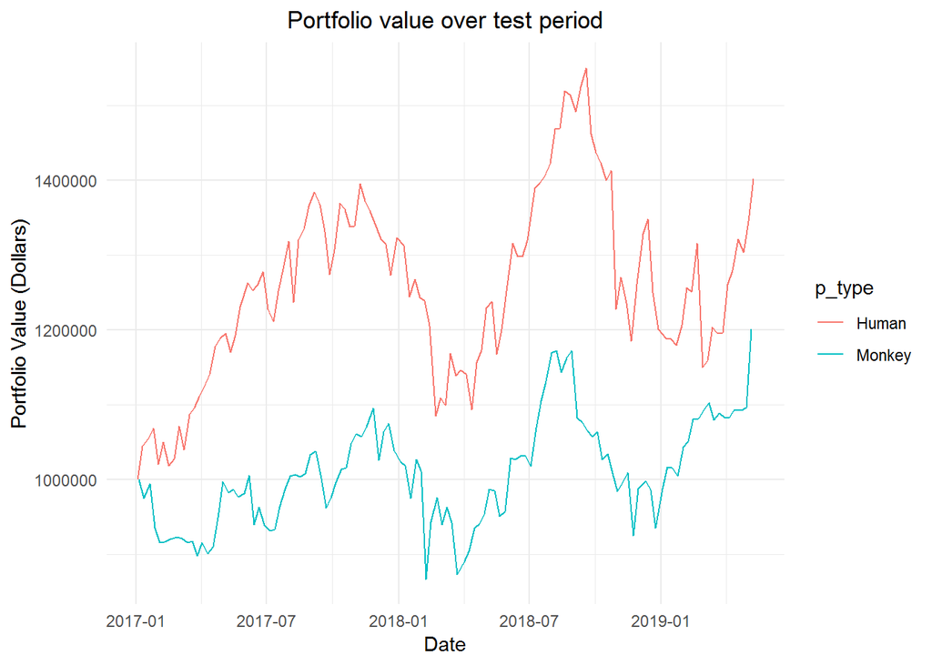

```r
p$p_type <- factor(p$p_type)
p <- p %>%
  arrange(date) %>%
  group_by(p_type)

# Plot the data

ggplot(data=p, aes(x=date, y=val, color=p_type)) +
  geom_line() +
  labs(title="Portfolio value over test period",
         x = "Date",
         y = "Portfolio Value (Dollars)") +
    theme(plot.title = element_text(hjust = 0.5))
```

## 5.1 Final Portfolio Values

### 5.1.1 Human Portfolio

Our human portfolio returned the following amount after the testing period:

```r
pfolio[[nrow(pfolio),17]]
```

```
## [1] 1401404
```

The return for the human portfolio was

```r
(pfolio[[nrow(pfolio),17]]-1000000)/1000000
```

```
## [1] 0.4014044
```

### 5.1.2 Monkey Portfolio

Our monkey portfolio returned the following amount after the testing period:

```r
pfolio_monkey[[nrow(pfolio_monkey),2]]
```

```
## [1] 1200470
```

The return for the monkey portfolio was

```r
(pfolio_monkey[[nrow(pfolio_monkey),2]]-1000000)/1000000
```

```
## [1] 0.2004698
```

# 6 Conclusion

Our tutorial confirms our initial hypothesis that humans outperform the theoretical monkeys in the arena of asset management. It does not, however, indicate that our particular strategy is ready for deployment in the real world. In application, our strategy’s returns would be diminished with the consideration of trading costs, be they liquidity demands or brokerage fees. Furthermore, we simplified many complications, which, in the real world, are unavoidable. For example, we can’t own fractions of a share, like in our program!

Furthermore, the theory of Arbitrage Pricing Theory neglects salient statistical metrics that are commonly used in data science to assess the applicability of a model, namely $p$-value assessment. Considering the overall design of our experiment, we could have returned more significant results by considering multiple monkey portfolios. As it stands, it is not sufficient to merely use one instance of a monkey portfolio. This decision, however, was made out of time constraints.

In conclusion, our tutorial confirms our hypothesis. That being said, our model is far from industry-ready. It can, however, be improved by combining concepts in data science and financial theory.

# 7 References

- For more information on the theoretical foundations of APT, consult
  - Financial Modeling of the Equity Market: From CAPM to Cointegration, available [here](https://onlinelibrary.wiley.com/doi/book/10.1002/9781119201236)
- For more information on factor choice, consult
  - Barra’s Risk Model Handbook, available [here](https://www.msci.com/www/research-paper/barra-s-risk-models/014972229)

# 8 Appendices

## 8.1 Appendix A: JSON to CSV

The following code was run once to extract the following daily historical data over the past 5 years from the date of the JSON call:

- The trading day
- The close price of the stock
- The high of the stock
- The low of the stock
- The volume of the stock
- The daily change in stock price

This data was extracted for the following equities, tradeable on the IEX exchange:

- AAPL: Apple Inc.
- CONE: CyrusOne Inc.
- FB: Facebook Inc. (Class A stock)
- GOOG: Google Inc. (Alphabet Class C stock)
- GOVT: iShares Core U.S. Treasury Bond ETF
- VZ: Verizon Communications Inc.

```r
##
# Returns a dataframe of date, close, high, low, and volume
#
# @param: tick
#         String, the stock ticker whose data we want
# @param: range
#         String, the range of data. We will use "5y"
#
# @author: Jared Gill
iex_chart <- function(tick, range){
  # Make REST call
  r <- GET("https://api.iextrading.com/1.0/stock/market/batch",
           query = list(symbols = tick,
                        types = "chart",
                        range = range, last = "5")
  )

  # Remove formatting
  r1 <- content(r)
  rtick <- enframe(unlist(r1[[tick]]$chart))

  # Extract data
  rdates <- filter(rtick, name=="date")
  rclose <- filter(rtick, name=="close")
  rhigh <- filter(rtick, name=="high")
  rlow <- filter(rtick, name=="low")
  rvolume <- filter(rtick, name=="volume")
  rchange <- filter(rtick, name=="change")

  # Make data frame
  df <- data.frame(rdates[2], rclose[2], rhigh[2], rlow[2], rvolume[2],
                   rchange[2])

  # Rename columns
  df <- df %>%
    rename(date="value", close="value.1", high="value.2", low="value.3",
           volume="value.4", change="value.5")
  return(df)
}

################################################################################
# Main
################################################################################

# Convert data to dataframes
df_aapl <- iex_chart("AAPL", "5y")
df_cone <- iex_chart("CONE", "5y")
df_fb <- iex_chart("FB", "5y")
df_goog <- iex_chart("GOOG", "5y")
df_govt <- iex_chart("GOVT", "5y")
df_vz <- iex_chart("VZ", "5y")

# Write to CSVs
write_csv(df_aapl, "aapl.csv")
write_csv(df_cone, "cone.csv")
write_csv(df_fb, "fb.csv")
write_csv(df_goog, "goog.csv")
write_csv(df_govt, "govt.csv")
write_csv(df_vz, "vz.csv")
```

## 8.2 Appendix B: Historical Balance Sheet Data

Initially, we attempted to obtain curated balance sheet data directly from the IEX Cloud service. This data, however, was limiting and lacked the accuracy we required.

Thus, the balance sheet data was scrapped by hand from the SEC’s [EDGAR Database](https://www.sec.gov/edgar/aboutedgar.htm). This process was *not* automated due to the uncompromising age of the database’s technology, which prevented even a simple parse of its HTML pages. As consequence, the balance sheet data was scrapped from each company’s 10-K and 10-Q SEC filings (10-K and 10-Q forms respectively are annual and quarterly reports on a company’s corporate standing). The following data was parsed:

- Annual Book Value
- Quarterly Outstanding Shares

This data was parsed for the following equities (click to be redirected to their respective 10-K and 10-Q filings on the EDGAR database):

- [AAPL](https://www.sec.gov/cgi-bin/browse-edgar?action=getcompany&CIK=0000320193&type=10&dateb=&owner=exclude&count=40)
- [CONE](https://www.sec.gov/cgi-bin/browse-edgar?action=getcompany&CIK=0001553023&type=10&dateb=&owner=exclude&count=40)
- [FB](https://www.sec.gov/cgi-bin/browse-edgar?action=getcompany&CIK=0001326801&type=10&dateb=&owner=exclude&count=40)
- GOOG: [before](https://www.sec.gov/cgi-bin/browse-edgar?action=getcompany&CIK=0001288776&type=10&dateb=&owner=exclude&count=40) and [after](https://www.sec.gov/cgi-bin/browse-edgar?action=getcompany&CIK=0001652044&type=10&dateb=&owner=exclude&count=40) the stock split.
- [VZ](https://www.sec.gov/cgi-bin/browse-edgar?action=getcompany&CIK=0000732712&type=10&dateb=&owner=exclude&count=40)

# 9 Glossary

**Asset**: Short for “financial asset,” which is a tradeable financial instrument.

**Change**: The change in an asset’s price from an initial time $t_i$ to a final time $t_f$. Defined as
$$P_{t_f} - P_{t_i}$$

**Close**: The price of an equity at the close of the trading day. The “price” of an equity is merely the dollar amount at which a transaction successfully occurred between seller and buyer. Thus, the close is the last transaction price for an equity on a specific trading day.

**Equity**: Used interchangeably with “stock.”

**High**: The highest price an equity achieved during the trading day.

**Low**: The lowest price an equity achieved during the trading day.

**Price**: Used interchangeably with “close.”

**Return**: The return of an asset $A$ is defined as
$$R = \frac{P_{t_i + \Delta t} - P_{t_i}}{P_{t_i}},$$
where $P_{t}$ refers to the price of $A$ at some time $t$. Thus, $P_{t_i}$ is the price of $A$ at some initial time $t_i$, and $P_{t_i + \Delta t}$ is the price of $A$ at some future time, where $\Delta t$ refers to the elapsed time since $t_i$.

**Risk-free Rate**: The return of the theoretical [risk-free asset](https://en.wikipedia.org/wiki/Risk-free_interest_rate).

**Volume**: The number of shares traded during a given period of time.